# Logo plot for active sites

# Sequence logo plots for peptides around active site

In this analysis we will create and compare logo plots for human- and mouse-entries with available “active site” information in uniprot.  
We do so first building sequence logo plots for different protein families. Later we zoom out and look at enzyme classes instead, as defined by the first digit of the EC number (see data augmentation steps).

## Load librares

```r
library(ggseqlogo)
library(patchwork)
library(tidyverse)
library(knitr)
```

## Load data

```r
aug_data <- read_delim(file = "../data/03_dat_aug.tsv",
                       delim = "\t")
```

## Identify protein families to look at

The purpose of this step is to identify the protein families where most information is available.  
The table in the output message will show the 10 most frequently observed protein families as an average across human and mice.

```r
# Filter out if no active site info
logoseq_data <- aug_data |>
  drop_na(logo_seq) |>
  filter(family_type == "family") |>
  select(entry,
         organism,
         protein_family,
         family_type,
         logo_seq)

# See what protein families with active site data occur most often in mouse
top_prot_fam_mouse <- logoseq_data |>
  drop_na(protein_family) |>
  filter(str_detect(organism,
                    "Mouse")) |>
  select(entry,
         protein_family,
         logo_seq) |>
  distinct() |>
  group_by(protein_family) |>
  summarize(n_mouse = n()) |>
  arrange(desc(n_mouse))

# See what protein families with active site data occur most often in human
top_prot_fam_human <- logoseq_data |>
  drop_na(protein_family) |>
  filter(organism == "Human") |>
  select(entry, protein_family, logo_seq) |>
  distinct() |>
  group_by(protein_family) |>
  summarize(n_human = n()) |>
  arrange(desc(n_human))

# Combine mouse and human protein family counts and available active site information
top_prot_fam <- top_prot_fam_mouse |>
  full_join(top_prot_fam_human,
            by = "protein_family") |>
  mutate(n_average = (n_mouse + n_human) /2) |>
  arrange(desc(n_average))

top_prot_fam |>
  slice(1:10)|> knitr::kable()
```

| protein_family | n_mouse | n_human | n_average |
| --- | --- | --- | --- |
| Peptidase S1 | 363 | 326 | 344.5 |
| Peptidase C19 | 100 | 133 | 116.5 |
| Protein-tyrosine phosphatase | 92 | 97 | 94.5 |
| Tyr protein kinase | 88 | 86 | 87.0 |
| CAMK Ser/Thr protein kinase | 79 | 72 | 75.5 |
| AGC Ser/Thr protein kinase | 60 | 64 | 62.0 |
| CMGC Ser/Thr protein kinase | 61 | 62 | 61.5 |
| Ser/Thr protein kinase | 62 | 60 | 61.0 |
| Lipase | 54 | 63 | 58.5 |
| STE Ser/Thr protein kinase | 54 | 54 | 54.0 |

```r
# Extract names of protein families in arranged order, to use for further analysis
top_prot_fam_name_vec <- top_prot_fam |>
  pull(protein_family)
```

## Logo plots for protein families

Here we use ggseqlogo() to visualize peptide sequences for each of the top 5 most frequently observed protein families as logo plots. The logo plots will be stitched together using both the inbuilt facet function of gggseqlogo() and patchwork.

The logo plot for mouse and human protein families are very similar, showing that mouse and human homologs very similar around the active sites. In addition, this analysis show how uniprot data can be utilized to gain knowledge about active sites for specific protein families.

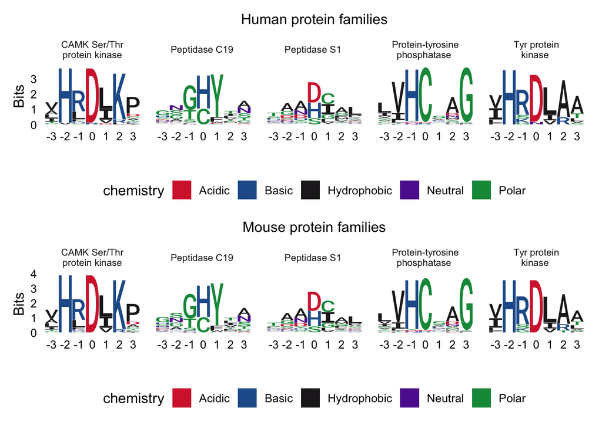

```r
### Protein family logo plots ###
# In this code chunk we work with the top 5 most frequently observed protein families

# Extract mouse data and filter out if no active site info
logoseq_data_mouse_prot <- aug_data |>
  drop_na(logo_seq, protein_family) |>
  filter(protein_family %in% top_prot_fam_name_vec[1:5]) |>
  filter(str_detect(organism, "Mouse")) |>
  select(entry,
         organism,
         protein_family,
         logo_seq) |>
  distinct()

# Extract human data and filter out if no active site info
logoseq_data_human_prot <- aug_data |>
  drop_na(logo_seq, protein_family) |>
  filter(protein_family %in% top_prot_fam_name_vec[1:5]) |>
  filter(str_detect(organism, "Human")) |>
  select(entry,
         organism,
         protein_family,
         logo_seq) |>
  distinct()

# Change proten family names to get line breaks (check if names match before changing them)
# Converting data to named list for use with facet function in ggseqlogo
# For mouse
logo_list_mouse_prot <- split(logoseq_data_mouse_prot$logo_seq,
                         logoseq_data_mouse_prot$protein_family) # named list needed to facet
logo_list_mouse_prot <- map(logo_list_mouse_prot,
                            unique) # Filter out identical sequences
names(logo_list_mouse_prot) <- c("CAMK Ser/Thr\nprotein kinase",
                                 "Peptidase C19 ",
                                 "Peptidase S1 ",
                                 "Protein-tyrosine\nphosphatase ",
                                 "Tyr protein\nkinase ")
# For human
logo_list_human_prot <- split(logoseq_data_human_prot$logo_seq,
                              logoseq_data_human_prot$protein_family) # named list needed to facet
logo_list_human_prot <- map(logo_list_human_prot,
                            unique) # Filter out identical sequences
names(logo_list_human_prot) <- c("CAMK Ser/Thr\nprotein kinase",
                                 "Peptidase C19 ",
                                 "Peptidase S1 ",
                                 "Protein-tyrosine\nphosphatase ",
                                 "Tyr protein\nkinase ")

# Making logo plot for mouse protein families
logo_plot_mouse_prot <- ggseqlogo(logo_list_mouse_prot,
                                  ncol=7) +
  ggtitle("Mouse protein families") +
  theme(plot.title = element_text(hjust = 0.5,
                                  size = 12),
        strip.text = element_text(size = 8)) +
  scale_x_continuous(breaks = 1:7,  # Existing tick positions
                     labels = -3:3  # Existing tick labels
  )
# Making logo plot for human protein families
logo_plot_human_prot <- ggseqlogo(logo_list_human_prot,
                                  ncol=7) +
  ggtitle("Human protein families") +
  theme(plot.title = element_text(hjust = 0.5,
                                  size = 12),
        strip.text = element_text(size = 8)) +
  scale_x_continuous(breaks = 1:7,  # Existing tick positions
                     labels = -3:3  # Existing tick labels
  )
# Combining mouse and human logo plot for protein families
logo_comb_prot <- logo_plot_human_prot / logo_plot_mouse_prot
logo_comb_prot
```

```r
# Save combined logo plot as png
ggsave(filename = "../results/06_logoplot_prot_fam.png",
       logo_comb_prot)
```

## Logo plots for enzyme class

Here we use ggseqlogo() to visualize peptide sequences for different types of enzyme classes according to the first digit in their EC number. We filtered out “translocases”, because very few entries very observed for this enzyme class resulting in an artifically high information content. The logo plots will be stitched together using both the inbuilt facet function of gggseqlogo() and patchwork.

Just as for the protein family logo plots, the logo plots for mouse and human enzyme classes are very similar. Enzyme classes are less specific than protein families, and thus we naturally observe lower information content in general. However we thought that “zooming out”, might reveal some differences between human and mice enzymes in general, but this was not the case.

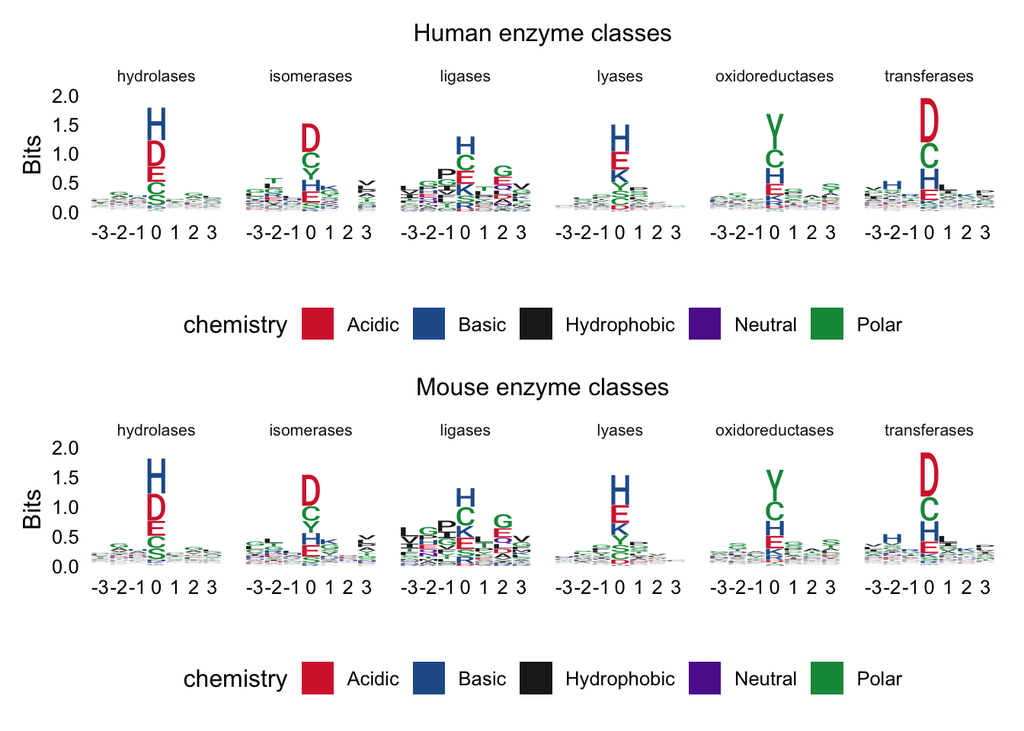

```r
### Enzyme class logo plots ###

# Extract mouse data and filter out if no active site info
logoseq_data_mouse_enz <- aug_data |>
  drop_na(logo_seq, enzyme_class) |>
  filter(str_detect(organism,
                    "Mouse")) |>
  # Removing translocases because limited data available
  filter(!enzyme_class == "translocases") |>
  select(entry,
         organism,
         enzyme_class,
         logo_seq) |>
  distinct()

# Extract human data and filter out if no active site info
logoseq_data_human_enz <- aug_data |>
  drop_na(logo_seq, enzyme_class) |>
  filter(str_detect(organism,
                    "Human")) |>
  # Removing translocases because limited data available
  filter(!enzyme_class == "translocases") |>
  select(entry,
         organism,
         enzyme_class,
         logo_seq) |>
  distinct()

# Converting data to named list for facet function in ggseqlogo: mouse data
logo_list_mouse_enz <- split(logoseq_data_mouse_enz$logo_seq,
                             logoseq_data_mouse_enz$enzyme_class)
logo_list_mouse_enz <- map(logo_list_mouse_enz,
                           unique) # Filter out identical sequences

# Converting data to named list for facet function in ggseqlogo: human data
logo_list_human_enz <- split(logoseq_data_human_enz$logo_seq,
                             logoseq_data_human_enz$enzyme_class)
logo_list_human_enz <- map(logo_list_human_enz,
                           unique) # Filter out identical sequences

# Making logo plots for mouse enzyme classses
logo_plot_mouse_enz <- ggseqlogo(logo_list_mouse_enz,
                                 ncol=6) +
  ggtitle("Mouse enzyme classes") +
  theme(plot.title = element_text(hjust = 0.5,
                                  size = 12),
        strip.text = element_text(size = 8)) +
  scale_x_continuous(breaks = 1:7,  # Existing tick positions
                     labels = -3:3  # Existing tick labels
  )
# Making logo plots for human enzyme classses
logo_plot_human_enz <- ggseqlogo(logo_list_human_enz,
                                 ncol=6) +
  ggtitle("Human enzyme classes") +
  theme(plot.title = element_text(hjust = 0.5,
                                  size = 12),
        strip.text = element_text(size = 8)) +
  scale_x_continuous(breaks = 1:7,  # Existing tick positions
                     labels = -3:3  # Existing tick labels
  )
# Combining mouse and human logo plots for enzyme classes
logo_comb_enz <- logo_plot_human_enz / logo_plot_mouse_enz
logo_comb_enz
```

```r
# Save combined logo plot
ggsave(filename = "../results/06_logoplot_enz.png",
       logo_comb_enz)
```